# Data Visualization: ggplot2 tutorial using gapminder dataset

If I can’t picture it, I can’t understand it. **Albert Einstein

## Overview

In this tutorial we look at some of the data on wealth and life expectancy of countries over time used by Hans Rosling, known as `gapminder`. The goal is to provide an overview of how to graph a variable (data) depending on its type, introduce some simple 1D and 2D plots constructed using `ggplot2()` and provide an outline of the layered grammar of graphics upon which `ggplot2()` is built.

## Learning objectives

> - Generate plots from data according to their type (discrete, continuous …)
> - Manage plot settings
> - Produce plots from data in a data frame
> - Modify and customize a plot
> - Create complex and fancy plot

### Loading/installing packages

```r
library(ggplot2) #for plotting
library(dplyr)    #for data manipulation
library(scales)  #for graphical scales
library(gapminder) #for dataset
library(plotly) # adds a frame aesthetic to ggplot, and allows interactive, linked views of a series of frames over time
```

Let’s have a look to our data structure

```r
str(gapminder)
```

```
## tibble [1,704 x 6] (S3: tbl_df/tbl/data.frame)
##  $ country  : Factor w/ 142 levels "Afghanistan",..: 1 1 1 1 1 1 1 1 1 1 ...
##  $ continent: Factor w/ 5 levels "Africa","Americas",..: 3 3 3 3 3 3 3 3 3 3 ...
##  $ year     : int [1:1704] 1952 1957 1962 1967 1972 1977 1982 1987 1992 1997 ...
##  $ lifeExp  : num [1:1704] 28.8 30.3 32 34 36.1 ...
##  $ pop      : int [1:1704] 8425333 9240934 10267083 11537966 13079460 14880372 12881816 13867957 16317921 22227415 ...
##  $ gdpPercap: num [1:1704] 779 821 853 836 740 ...
```

The print() method gives an abbreviated printout.

```r
gapminder
```

```
## # A tibble: 1,704 x 6
##    country     continent  year lifeExp      pop gdpPercap
##    <fct>       <fct>     <int>   <dbl>    <int>     <dbl>
##  1 Afghanistan Asia       1952    28.8  8425333      779.
##  2 Afghanistan Asia       1957    30.3  9240934      821.
##  3 Afghanistan Asia       1962    32.0 10267083      853.
##  4 Afghanistan Asia       1967    34.0 11537966      836.
##  5 Afghanistan Asia       1972    36.1 13079460      740.
##  6 Afghanistan Asia       1977    38.4 14880372      786.
##  7 Afghanistan Asia       1982    39.9 12881816      978.
##  8 Afghanistan Asia       1987    40.8 13867957      852.
##  9 Afghanistan Asia       1992    41.7 16317921      649.
## 10 Afghanistan Asia       1997    41.8 22227415      635.
## # ... with 1,694 more rows
```

It is useful to get some overview of the variables before getting started.

```r
summary(gapminder)
```

```
##         country        continent        year         lifeExp
##  Afghanistan:  12   Africa  :624   Min.   :1952   Min.   :23.60
##  Albania    :  12   Americas:300   1st Qu.:1966   1st Qu.:48.20
##  Algeria    :  12   Asia    :396   Median :1980   Median :60.71
##  Angola     :  12   Europe  :360   Mean   :1980   Mean   :59.47
##  Argentina  :  12   Oceania : 24   3rd Qu.:1993   3rd Qu.:70.85
##  Australia  :  12                  Max.   :2007   Max.   :82.60
##  (Other)    :1632
##       pop              gdpPercap
##  Min.   :6.001e+04   Min.   :   241.2
##  1st Qu.:2.794e+06   1st Qu.:  1202.1
##  Median :7.024e+06   Median :  3531.8
##  Mean   :2.960e+07   Mean   :  7215.3
##  3rd Qu.:1.959e+07   3rd Qu.:  9325.5
##  Max.   :1.319e+09   Max.   :113523.1
##
```

We will want to look at trends over time by `continent`. How many countries are in this data set in each continent? There are 12 years for each country. Are the data complete? `table()` gives an answer.

```r
table(gapminder$continent, gapminder$year)
```

```
##
##            1952 1957 1962 1967 1972 1977 1982 1987 1992 1997 2002 2007
##   Africa     52   52   52   52   52   52   52   52   52   52   52   52
##   Americas   25   25   25   25   25   25   25   25   25   25   25   25
##   Asia       33   33   33   33   33   33   33   33   33   33   33   33
##   Europe     30   30   30   30   30   30   30   30   30   30   30   30
##   Oceania     2    2    2    2    2    2    2    2    2    2    2    2
```

**Note:** we used the `$` symbol with `data$variable` notation because `table()` doesn’t have a `data=` argument. Another way to do this is to use the `with()` function, that makes variables in a data set available directly. The same table can be obtained using:

```r
with(gapminder, {table(continent, year)})
```

```
##           year
## continent  1952 1957 1962 1967 1972 1977 1982 1987 1992 1997 2002 2007
##   Africa     52   52   52   52   52   52   52   52   52   52   52   52
##   Americas   25   25   25   25   25   25   25   25   25   25   25   25
##   Asia       33   33   33   33   33   33   33   33   33   33   33   33
##   Europe     30   30   30   30   30   30   30   30   30   30   30   30
##   Oceania     2    2    2    2    2    2    2    2    2    2    2    2
```

## 1D plots: Bar plots for discrete variables

As we have seen previously during the lecture, the distribution of a categorical variable is better vizualised using a bar plot. For example, `continent`. With ggplot2, this is relatively easy:

- we start by mapping the `x` variable to `continent`
- then, we add a `geom_bar()` layer, that counts the observations in each category and plots them as bar lengths.

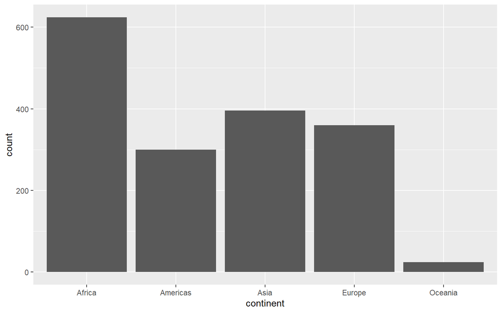

```r
ggplot(gapminder, aes(x=continent)) + geom_bar()
```

To make this more colorful, you can also map the `fill` attribute to `continent`.

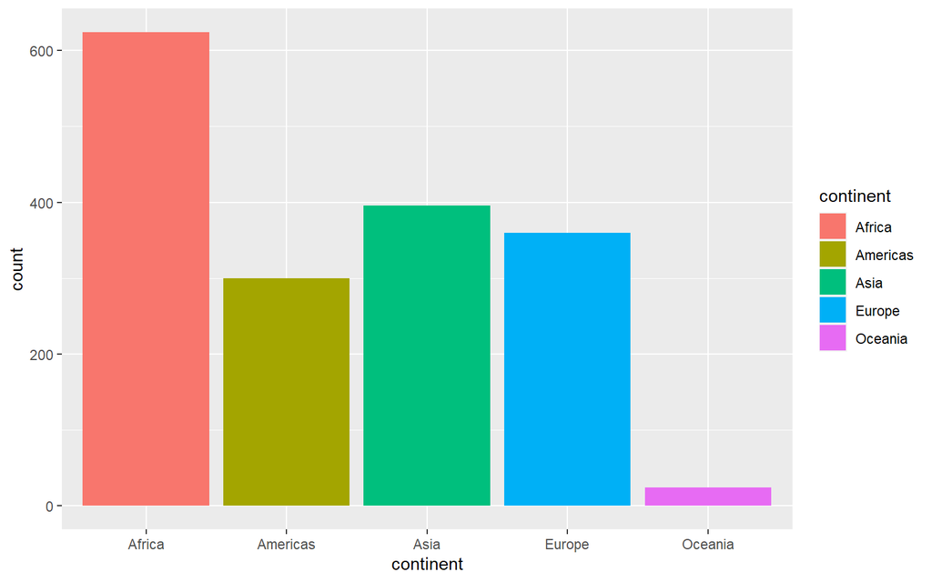

```r
ggplot(gapminder, aes(x=continent, fill=continent)) + geom_bar()
```

With ggplot2 features, we will be able also to:

- change the default color schemes
- modify labels
- change the legend position, or eliminate it in same case
- flip axis …

Let’s try some !

- We will change the y axis, `count`, in `geom_bar()` to `..count../12` in order to represent the number of countries.
- Change the label of the y axis by a more meaningful one: `countries`
- Suppress the default legend for continent, which is redundant in this case

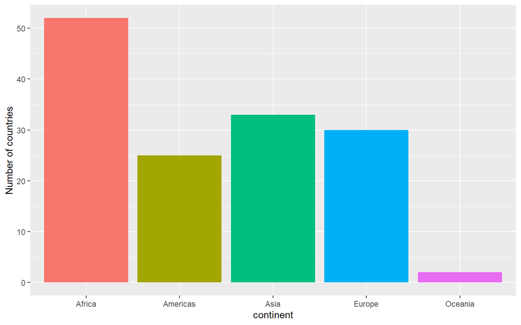

```r
ggplot(gapminder, aes(x=continent, fill=continent)) +
    geom_bar(aes(y= ..count../12)) +
    labs(y="Number of countries") +
    guides(fill=FALSE)
```

**Note:** Ever plot in `ggplot2` is a `ggplot` object.

If you want to save a given plot for a future use, store it in a variable by using: `mybar <- ggplot() + ...` `

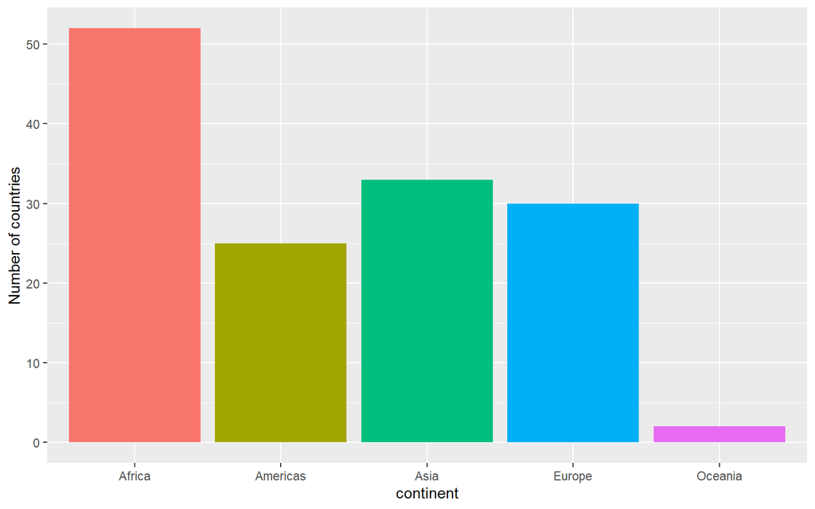

```r
mybar <- ggplot(gapminder, aes(x=continent, fill=continent)) +
    geom_bar(aes(y=..count../12)) +
    labs(y="Number of countries") +
    guides(fill=FALSE)
mybar
```

Some other ggplot2 features

- Transforming coordinates using `coord_trans` function

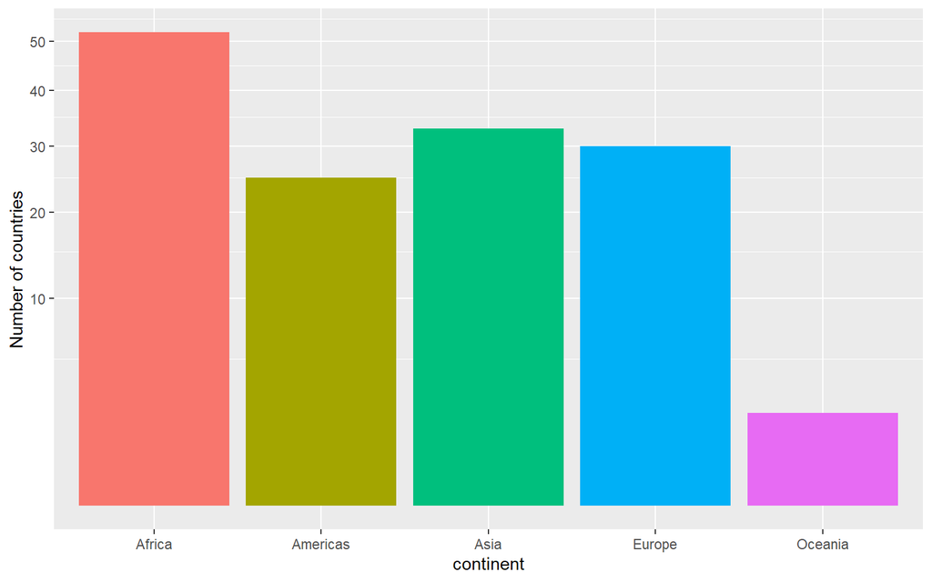

```r
mybar + coord_trans(y="sqrt")
```

- Flipping axes using `coord_flip` function

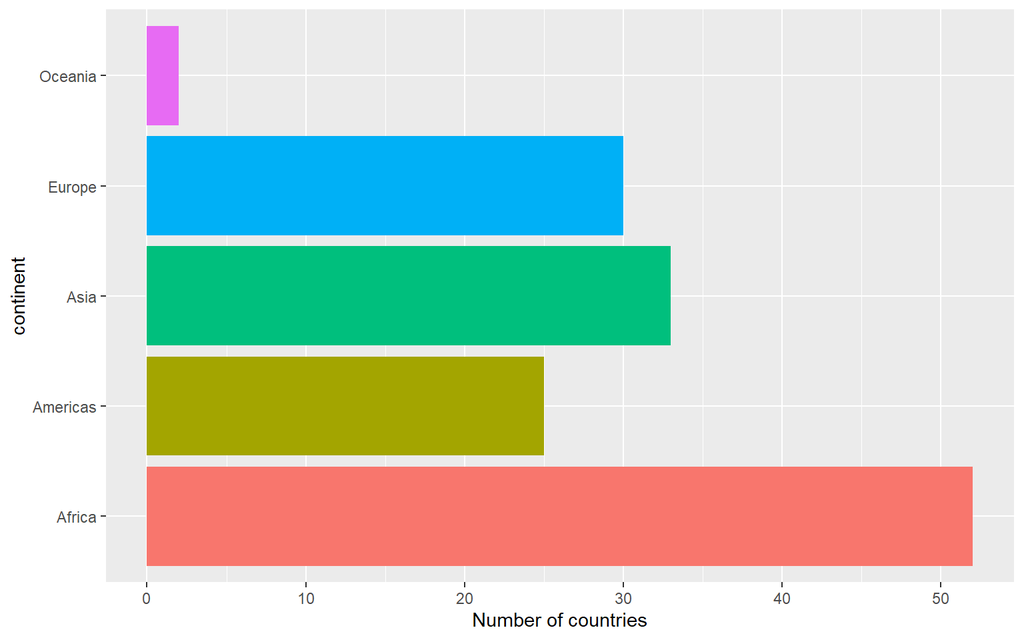

```r
mybar + coord_flip()
```

- Transform to polar coordinates

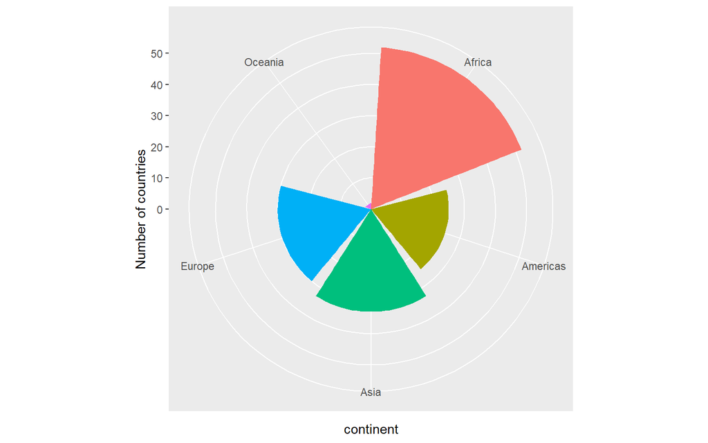

```r
mybar + coord_polar()
```

## 1D plots: density plots for continuous variables

The `gapminder` data set contains several continuous variables: life expectancy (`lifeExp`), population (`pop`) and gross domestic product per capita (`gdpPercap`) for each year and country. For such variables, density plots provide a useful graphical summary.

Let’s start by exploring life expectancy. The simplest plot uses this as the horizontal axis, `aes(x=lifeExp)` and then adds `geom_density()` to calculate and plot the smoothed frequency distribution.

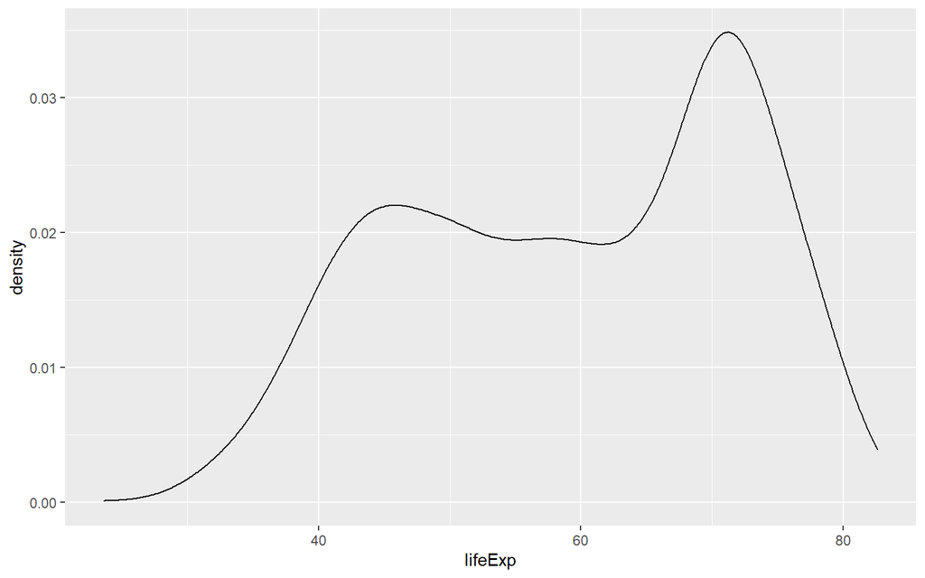

```r
ggplot(data=gapminder, aes(x=lifeExp)) +
    geom_density()
```

We have several features to make this plot prettier. Changing the line thickness (`size=`), add a fill color (`fill=""`), and make the fill color partially transparent (`alpha=`).

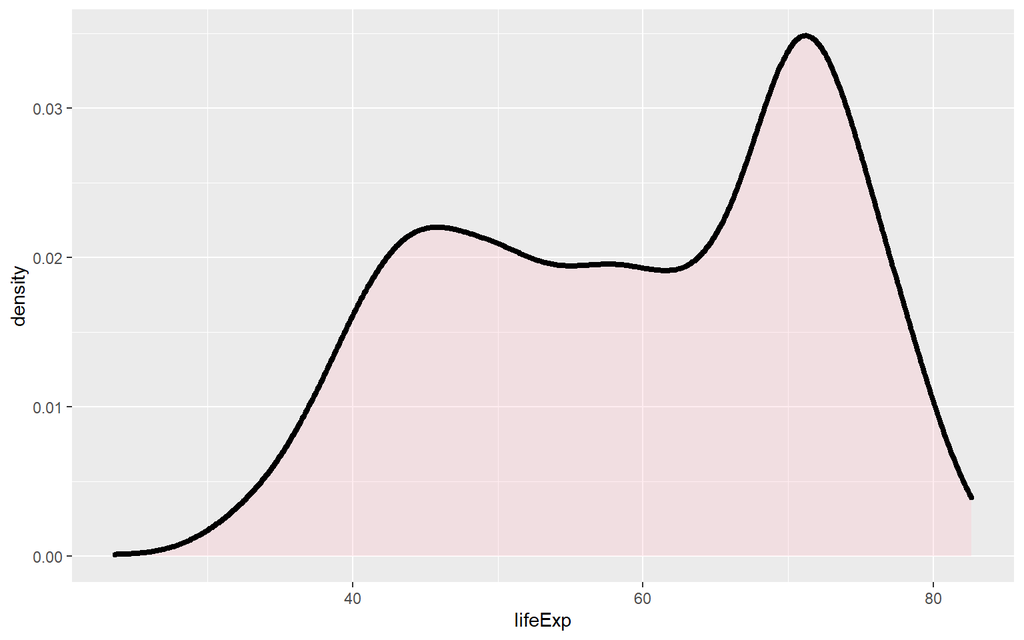

```r
ggplot(data=gapminder, aes(x=lifeExp)) +
    geom_density(size=1.5, fill="pink", alpha=0.3)
```

### Differences by continent

The plot of lifeExp is bimodal, and looks not obvious. We need to add another aesthetic attribute, `fill=continent`, which is inherited in `geom_density()` to see more details about countries among continents.

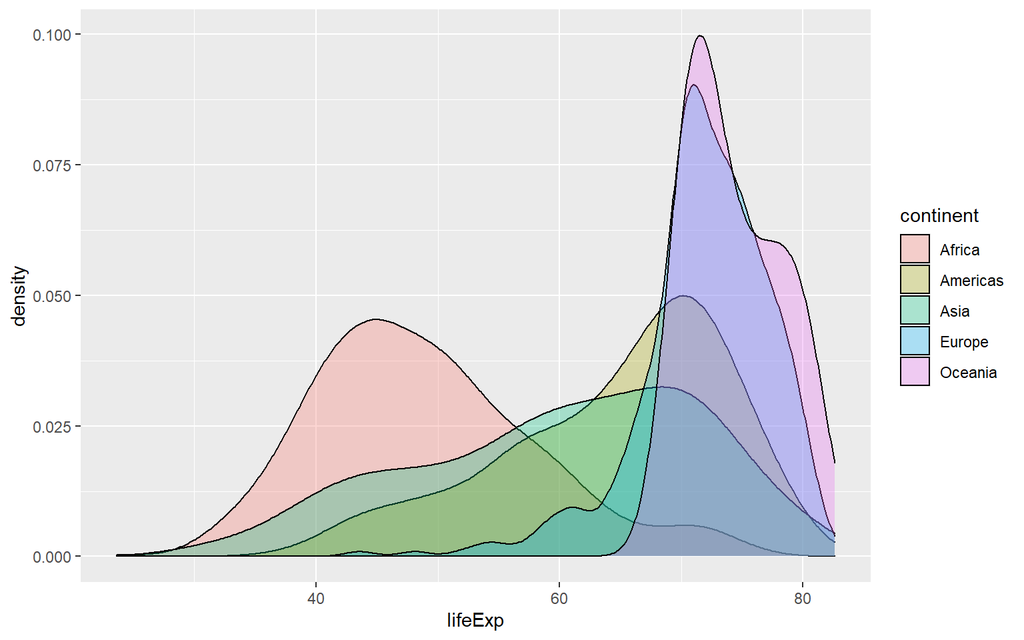

```r
ggplot(data=gapminder, aes(x=lifeExp, fill=continent)) +
    geom_density(alpha=0.3)
```

**Note 1:** We used transparent colors (`alpha=`) to see more clearly the different distributions across continent.

**Note 2:** It is easy now to see that African countries differ markedly from the rest.

### boxplots and other visual summaries

You might want to visualize the distributions of life expectancy by another visual summary, grouped by `continent`. All you need to do is change the aesthetic to show `continent` on one axis, and life expectancy (`lifeExp`) on the other.

```r
gap1 <- ggplot(data=gapminder, aes(x=continent, y=lifeExp, fill=continent))
```

Then, add a`geom_boxplot()` layer:

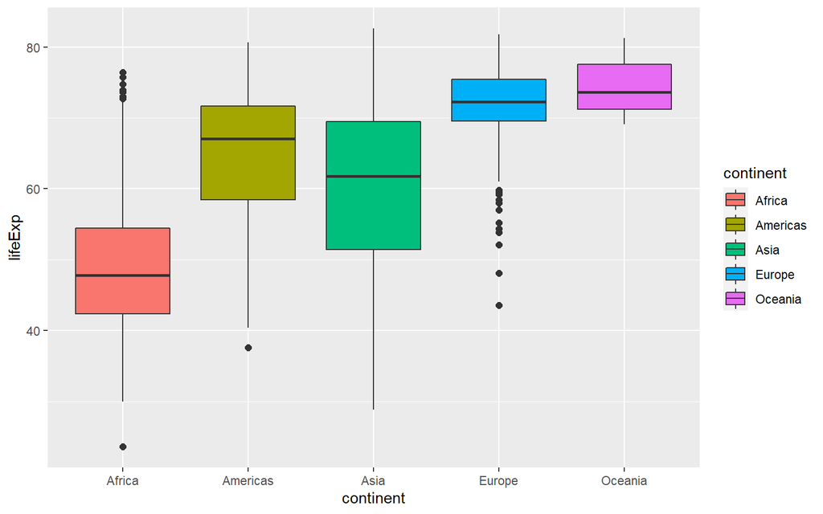

```r
gap1 +
    geom_boxplot(outlier.size=2)
```

#### Challenge 1

- Remove the legend from this plot
- Make the plot horizontal
- Instead of a boxplot, try `geom_violin()`

### Effect ordering

The continents are a factor, and are ordered alphabetically by default. It might be more useful to order them by the mean or median life expectancy.

In this example, I use the `dplyr` “pipe” notation (`%>%`) to send the `gapminder` data to the `dplyr:;mutate()` function, and within that, `reorder()` the continents by their median life expectancy.

```r
gapminder %>%
    mutate(continent = reorder(continent, lifeExp, FUN=median))
```

```
## # A tibble: 1,704 x 6
##    country     continent  year lifeExp      pop gdpPercap
##    <fct>       <fct>     <int>   <dbl>    <int>     <dbl>
##  1 Afghanistan Asia       1952    28.8  8425333      779.
##  2 Afghanistan Asia       1957    30.3  9240934      821.
##  3 Afghanistan Asia       1962    32.0 10267083      853.
##  4 Afghanistan Asia       1967    34.0 11537966      836.
##  5 Afghanistan Asia       1972    36.1 13079460      740.
##  6 Afghanistan Asia       1977    38.4 14880372      786.
##  7 Afghanistan Asia       1982    39.9 12881816      978.
##  8 Afghanistan Asia       1987    40.8 13867957      852.
##  9 Afghanistan Asia       1992    41.7 16317921      649.
## 10 Afghanistan Asia       1997    41.8 22227415      635.
## # ... with 1,694 more rows
```

**Note:** In other situations, you could use `FUN=mean`, `FUN=sd`, or `FUN=max` to sort the levels by their means, standard deviatons, maximums, or any other function.

We can now pipe the result of this right into `ggplot`:

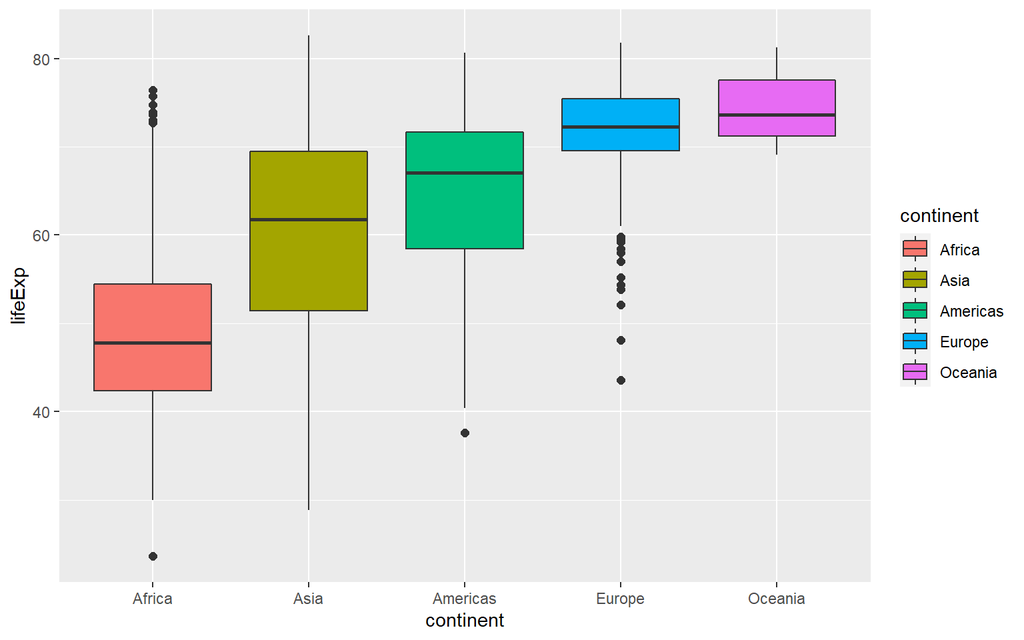

```r
gapminder %>%
    mutate(continent = reorder(continent, lifeExp, FUN=median)) %>%
    ggplot(aes(x=continent, y=lifeExp, fill=continent)) +
    geom_boxplot(outlier.size=2)
```

### Exploring at GDP

Let’s look at the distribution of `gdpPercap` in a similar way, starting with the unconditional distribution.

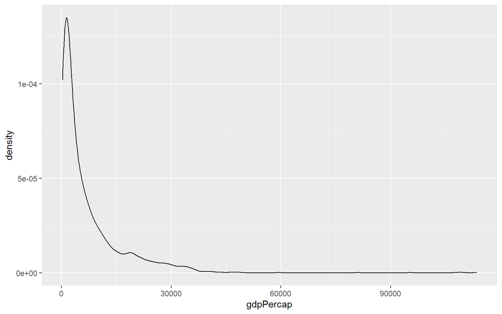

```r
ggplot(data=gapminder, aes(x=gdpPercap)) +
    geom_density()
```

#### Challenge 2

- As we did for `lifeExp` plot the distributions separately for each continent
- It is probably more useful to plot GDP on a log scale. Add another layer that transforms the `x` axis to `log10(gdpPercap)`.
- Make boxplots of `gdpPercap` by `continent`.
- Do the same, but plot GDP on a log scale.

## 1.5D: Layers & Time series plots

#### Layers

Exploring how life expectancy change with GDP per country, for expample china. We can use `geom_line` to make a line plot.

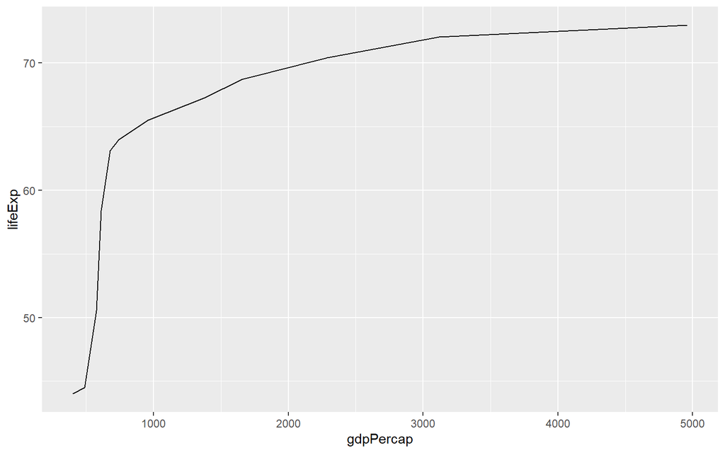

```r
china <- ggplot(subset(gapminder, country =="China"), #subsetting data
            aes(x=gdpPercap, y=lifeExp))
china + geom_line()
```

We can use both `geom_line` and `geom_point` to make a line plot with points at the data values.

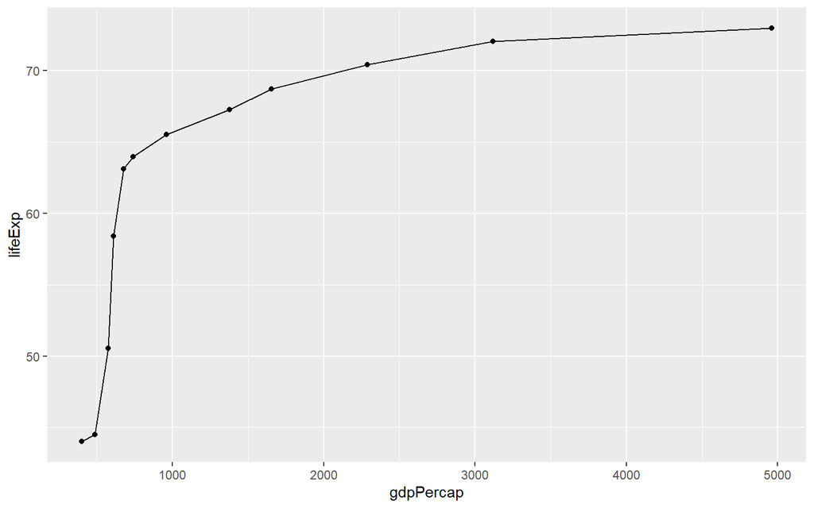

```r
china + geom_line() + geom_point()  #adding points to data values
```

**Note:** This brings up another important concept with ggplot2: layers. A given plot can have multiple layers of geometric objects, plotted one on top of the other.

If we make the lines and points different colors, we can see that points are placed on top of the lines, since they are in the second layer.

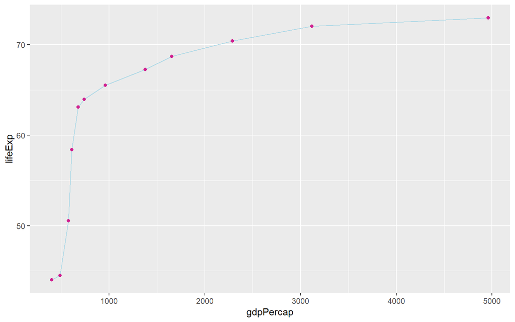

```r
china + geom_line(color="lightblue") + geom_point(color="violetred") #adding some colors
```

If we switch the order of `geom_point()` and `geom_line()`, we’ll reverse the layers.

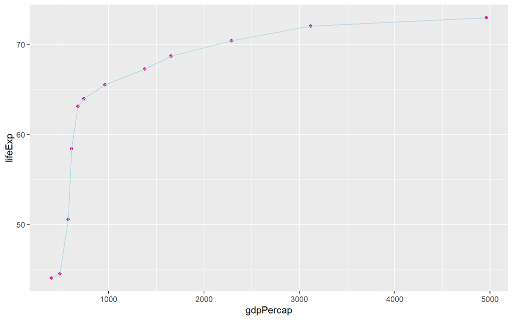

```r
china + geom_point(color="violetred") + geom_line(color="lightblue")
```

**Note:** aesthetics that are included in the call to `ggplot2()` (or completely separately) are made to be the defaults for all layers, but we can separately control the aesthetics for each layer. For example, we could color the points by year:

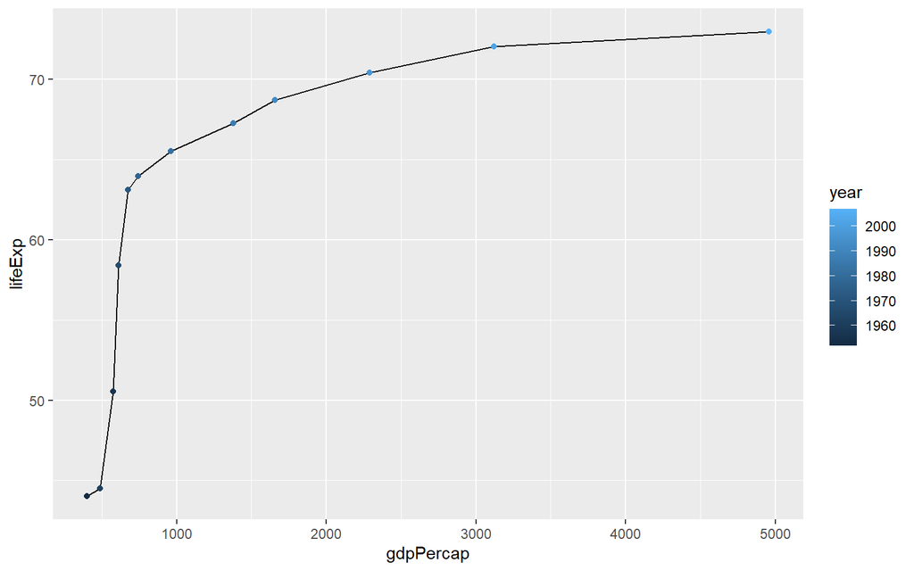

```r
china + geom_line() + geom_point(aes(color=year)) #color the point by year
```

With a rainbow:

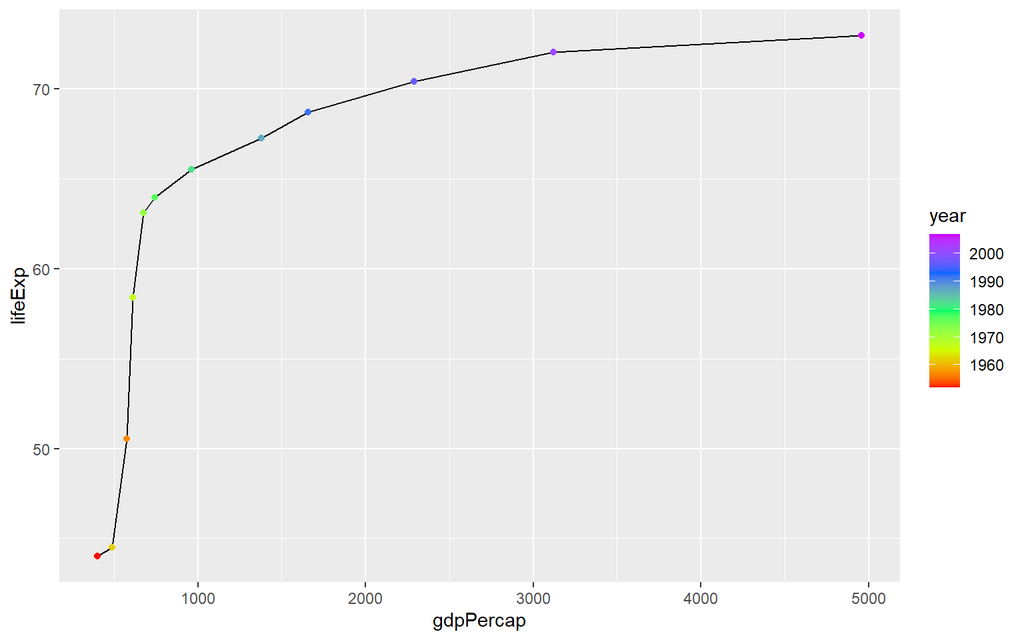

```r
china + geom_line() + geom_point(aes(color=year))+ scale_color_gradientn(colours = rainbow(5)) #with a rainbow
```

Coloring both points and lines:

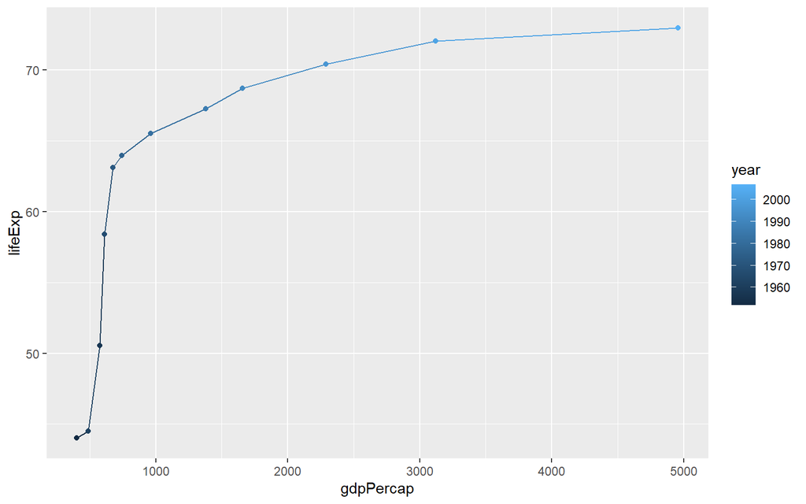

```r
china + geom_line() + geom_point() + aes(color=year) #coloring both point and line
```

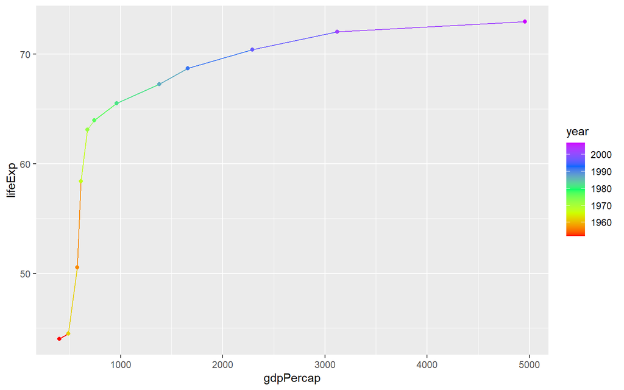

```r
china + geom_line() + geom_point() + aes(color=year)+ scale_color_gradientn(colours = rainbow(5)) #both with rainbow shade
```

#### Challenge 3

- Make a plot of `lifeExp` vs `gdpPercap` for China and India, with both lines and points.

#### Time series plot

Exploring how has life expectancy changed over time. The simplest way to to plot a line for each country over `year`. To do this, we use the `group` aesthetic.

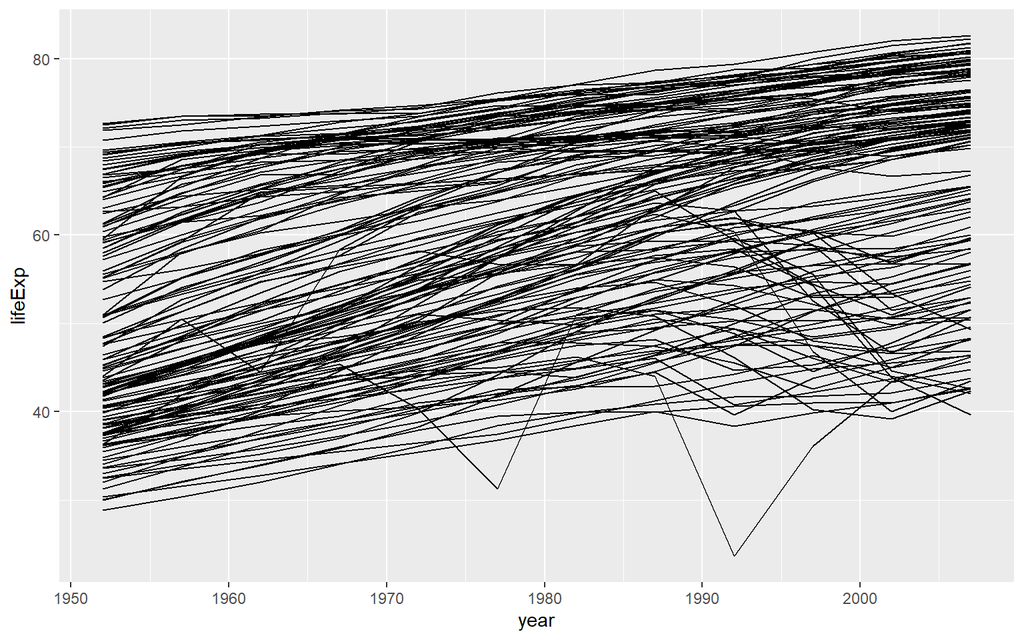

```r
ggplot(gapminder, aes(x=year, y=lifeExp, group=country)) + #using the aesthetic group
  geom_line()
```

Adding colors:

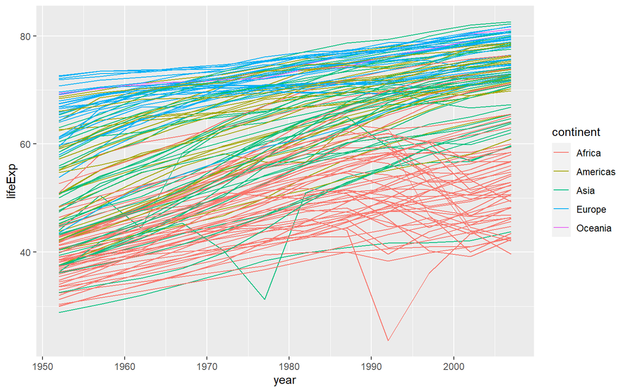

```r
ggplot(gapminder, aes(x=year, y=lifeExp, group=country , color = continent)) + #adding color
  geom_line()
```

Changing colors shade:

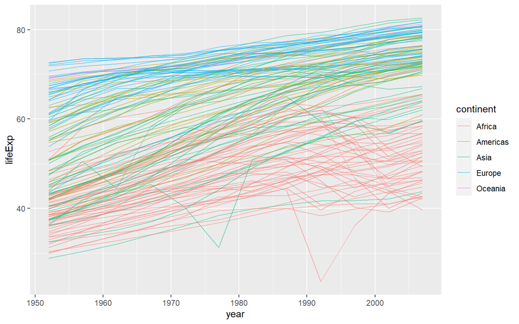

```r
ggplot(gapminder, aes(x=year, y=lifeExp, group=country , color = continent)) + #changing colors shade
  geom_line(alpha = 0.5)
```

## Plotting a summary

A better look at trends over time is to find the mean or median for each `year` and `continent` and plot those.

```r
gapminder %>%
  group_by(continent, year) %>%
  summarise(lifeExp=median(lifeExp)) %>% head() #median for each year and continent
```

```
## # A tibble: 6 x 3
## # Groups:   continent [1]
##   continent  year lifeExp
##   <fct>     <int>   <dbl>
## 1 Africa     1952    38.8
## 2 Africa     1957    40.6
## 3 Africa     1962    42.6
## 4 Africa     1967    44.7
## 5 Africa     1972    47.0
## 6 Africa     1977    49.3
```

One nice feature of the `dplyr` and `tidyverse` framework, is that you can pipe the result of such a summary directly to `ggplot()`:

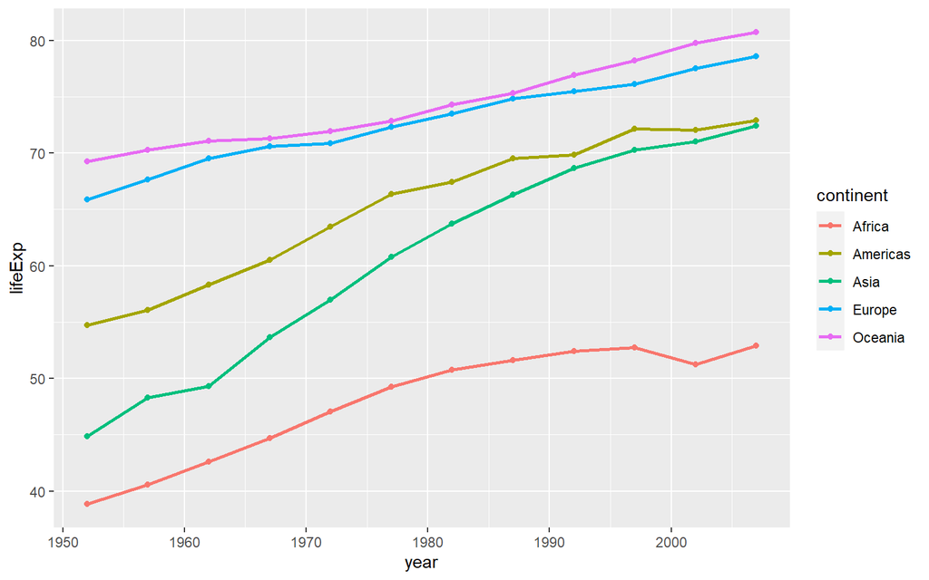

```r
gapminder %>% #piping to ggplot
  group_by(continent, year) %>%
  summarise(lifeExp=median(lifeExp)) %>%
  ggplot(aes(x=year, y=lifeExp, color=continent)) +
  geom_line(size=1) +
  geom_point(size=1.5)
```

If you want to make several plots of such a summarized data set, save the result in a new object.

```r
gapminder %>% #saving in a new dataset using assignement
  group_by(continent, year) %>%
  summarise(lifeExp=median(lifeExp)) -> gapyear
```

Let’s play with our plot and make it more fancy!

We can fit linear regression lines for each `continent` instead of joining all the points:

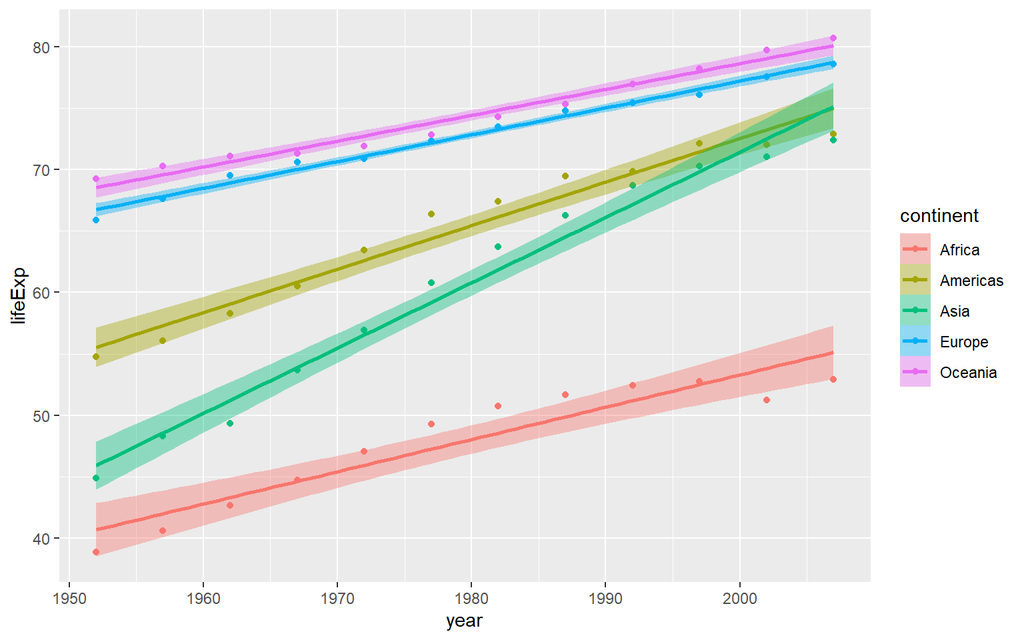

```r
ggplot(gapyear, aes(x=year, y=lifeExp, color=continent)) +  #fitting linear regression lines for each continent
  geom_point(size=1.5) +
  geom_smooth(aes(fill=continent), method="lm")
```

We can also use a `loess` smooth rather than a linear regression:

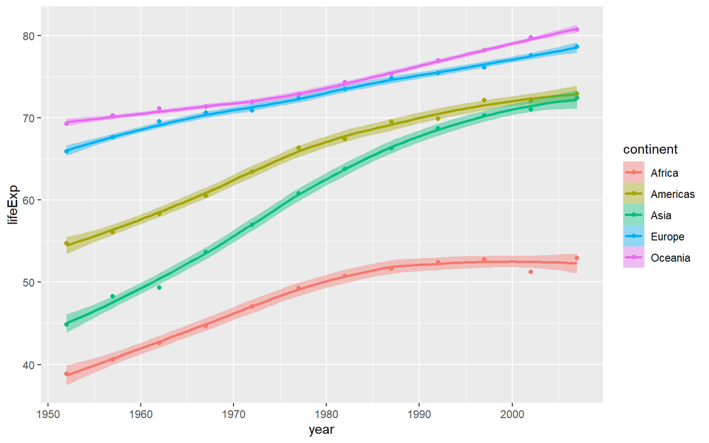

```r
ggplot(gapyear, aes(x=year, y=lifeExp, color=continent)) +  #using a loess smooth
  geom_point(size=1.5) +
  geom_smooth(aes(fill=continent), method="loess")
```

We can change the default use of legends by placing it inside the plot:

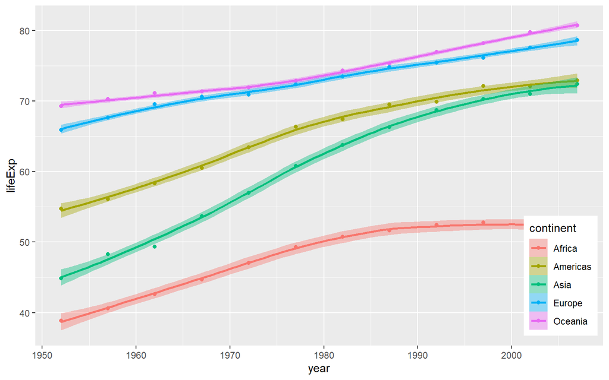

```r
ggplot(gapyear, aes(x=year, y=lifeExp, color=continent)) +  #using a loess smooth
  geom_point(size=1.5) +
  theme(
    legend.position = c(0.99, 0.03),
    legend.justification = c("right", "bottom") #placing the legend inside the plot
  )+
  geom_smooth(aes(fill=continent), method="loess")
```

## 2D: Scatterplots

Let’s explore the relationship between life expectancy and GDP with a scatterplot,

A basic scatterplot is set up by assigning two variables to the `x` and `y` aesthetic attributes then we can add the points in another layer.

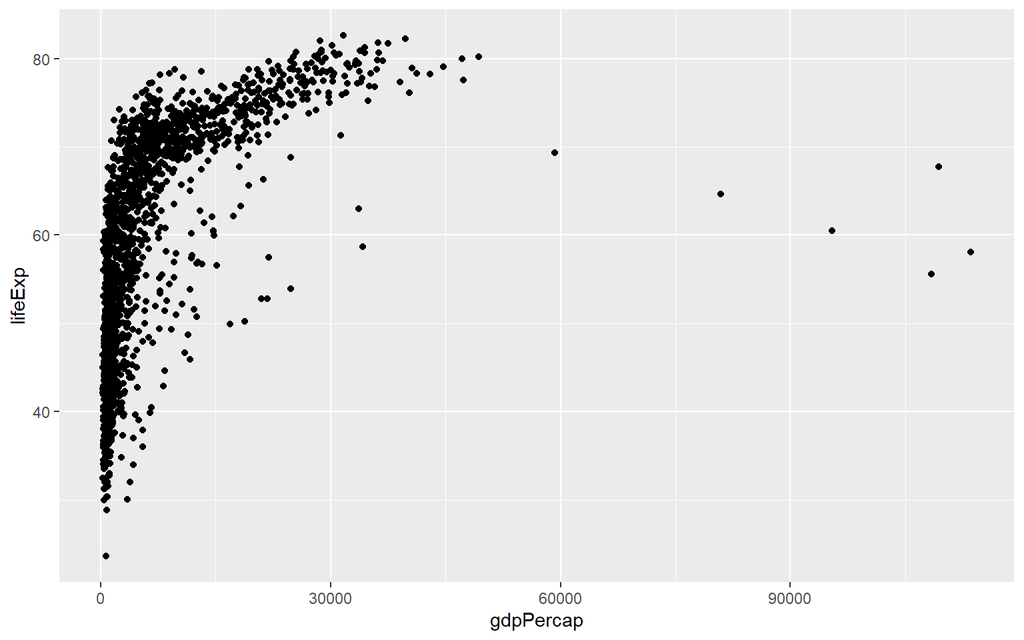

```r
plt <- ggplot(data=gapminder,
              aes(x=gdpPercap, y=lifeExp))
plt + geom_point()
```

Or, color them by continent.

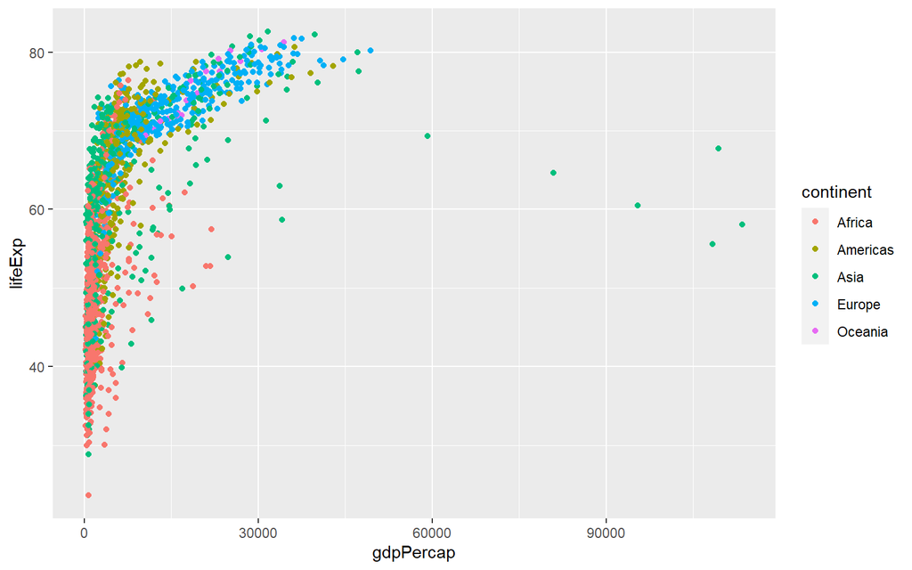

```r
plt + geom_point(aes(color=continent)) #adding color by continent
```

For a better look, we can also add a smoothed curve for all the data:

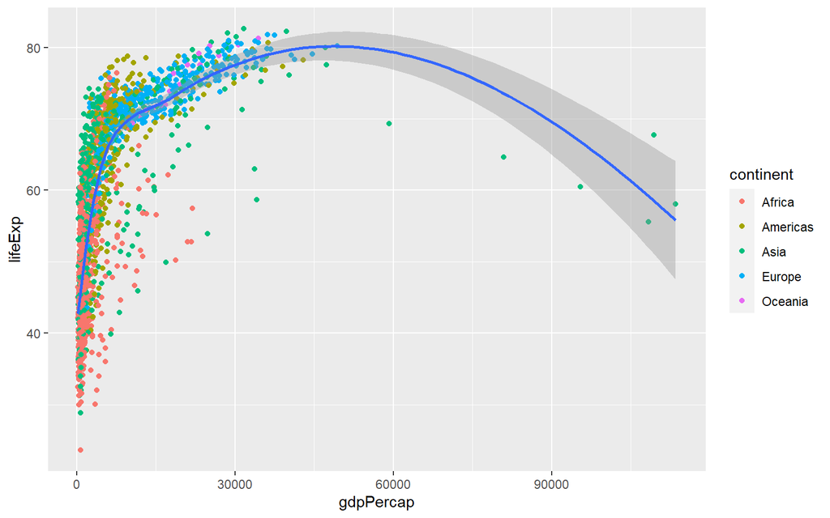

```r
plt + geom_point(aes(color=continent)) +
  geom_smooth(method="loess")  #adding a smoothed curve for all the data
```

As we have seen earlier about GDP, this variable is better plotted on a log scale:

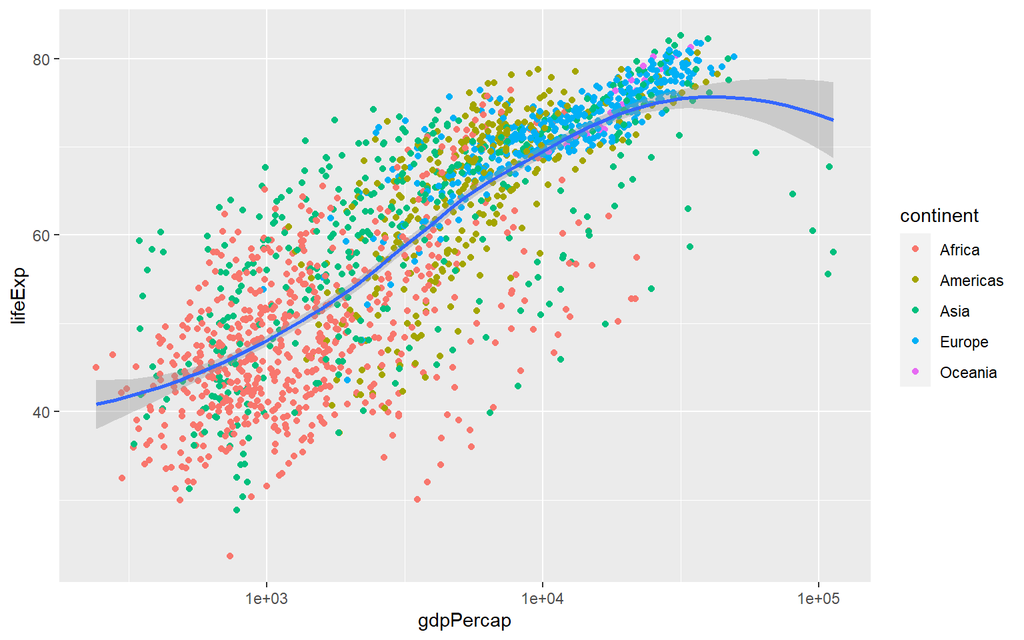

```r
plt + geom_point(aes(color=continent)) +
  geom_smooth(method="loess") +
  scale_x_log10()     #plotting on a log scale
```